# Analytics and Systems of Big Data Assignment

## Descriptive Analytics

The dataset used is the “US States Plants dataset" from Plants Database.  
https://plants.sc.egov.usda.gov/java/stateDownload?statefips=US08

### Importing all necessary libraries

```python
import pandas as pd
import numpy as np
import seaborn as sns
import matplotlib.pyplot as plt
import math

#pip install missingno
import missingno as msno
import statistics as stats
import scipy.stats as ss
import scipy.cluster.hierarchy as sch
#pip install statsmodels
import statsmodels.api as sm

from collections import Counter
#pip install -U scikit-learn
from sklearn.impute import KNNImputer
```

Reading the Dataset (dataset.txt)

```python
data = pd.read_csv('dataset.txt', sep=",")
data.head()
```

|  | Symbol | Synonym Symbol | Scientific Name with Author | National Common Name | Family |
| --- | --- | --- | --- | --- | --- |
| 0 | ABAR | NaN | Abronia argillosa S.L. Welsh & Goodrich | clay sand verbena | Nyctaginaceae |
| 1 | ABCA | NaN | Abronia carletonii J.M. Coult. & Fisher | Carleton's sand verbena | Nyctaginaceae |
| 2 | ABCO | NaN | Abies concolor (Gord. & Glend.) Lindl. ex Hild... | white fir | Pinaceae |
| 3 | ABCO | ABCOC | Abies concolor (Gord. & Glend.) Lindl. ex Hild... | NaN | Pinaceae |
| 4 | ABEL | NaN | Abronia elliptica A. Nelson | fragrant white sand verbena | Nyctaginaceae |

```python
data.shape
```

```
(15436, 5)
```

- The dataset has 15436 observations and 5 features.

```python
data.info()
```

```
<class 'pandas.core.frame.DataFrame'>
RangeIndex: 15436 entries, 0 to 15435
Data columns (total 5 columns):
Symbol                         15436 non-null object
Synonym Symbol                 9916 non-null object
Scientific Name with Author    15436 non-null object
National Common Name           5509 non-null object
Family                         15436 non-null object
dtypes: object(5)
memory usage: 603.1+ KB
```

- The output tells us that all our features are **categorical variables** we have some **NaN/missing values** in the columns **"Synonym Symbol"** and **"National Common Name"**.

```python
data.describe()
```

|  | Symbol | Synonym Symbol | Scientific Name with Author | National Common Name | Family |
| --- | --- | --- | --- | --- | --- |
| count | 15436 | 9916 | 15436 | 5509 | 15436 |
| unique | 5520 | 9916 | 15436 | 4224 | 151 |
| top | MIGU | STED | Delphinium ×occidentale (S. Watson) S. Watson ... | rubber rabbitbrush | Asteraceae |
| freq | 70 | 1 | 1 | 12 | 2728 |

This describes the statistics of the data.

```python
data.isna().sum()
```

```
Symbol                            0
Synonym Symbol                 5520
Scientific Name with Author       0
National Common Name           9927
Family                            0
dtype: int64
```

- "Synonym Symbol" has 5520 NaN values and "National Common Name" has 9927 NaN values.

```python
nan_values = data.isna().sum()
nan_values = nan_values / len(data)*100
nan_values = nan_values[nan_values > 0]
nan_values
```

```
Synonym Symbol          35.760560
National Common Name    64.310702
dtype: float64
```

- Approximately 36% of "Synonym Symbol" column has NaN values and 64% of "National Common Name" has NaN values.

#### Visual Representation of Percentage of NaN values

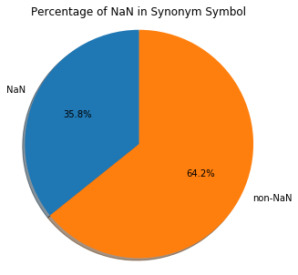

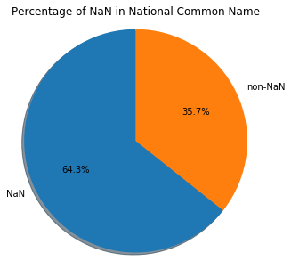

```python
labels = 'NaN', 'non-NaN'
plt.rcParams['figure.figsize'] = [5 ,5]

fig1, ax1 = plt.subplots()
sizes=[nan_values['Synonym Symbol'],100-nan_values['Synonym Symbol']]
ax1.pie(sizes, labels=labels, autopct='%1.1f%%',shadow=True, startangle=90)
ax1.axis('equal')
plt.title('Percentage of NaN in Synonym Symbol')

fig1, ax2 = plt.subplots()
sizes=[nan_values['National Common Name'],100-nan_values['National Common Name']]
ax2.pie(sizes, labels=labels, autopct='%1.1f%%',shadow=True, startangle=90)
ax2.axis('equal')
plt.title('Percentage of NaN in National Common Name')

plt.show()
```

```python
print(data['Family'].nunique())
data['Family'].unique()
```

```
151
```

```
array(['Nyctaginaceae', 'Pinaceae', 'Malvaceae', 'Poaceae',
       'Acarosporaceae', 'Acoraceae', 'Ranunculaceae', 'Aceraceae',
       'Asteraceae', 'Pteridaceae', 'Adoxaceae', 'Scrophulariaceae',
       'Lamiaceae', 'Caryophyllaceae', 'Rosaceae', 'Simaroubaceae',
       'Apiaceae', 'Liliaceae', 'Brassicaceae', 'Alismataceae',
       'Polemoniaceae', 'Fabaceae', 'Betulaceae', 'Amaranthaceae',
       'Apocynaceae', 'Boraginaceae', 'Lythraceae', 'Primulaceae',
       'Saururaceae', 'Araliaceae', 'Viscaceae', 'Ericaceae',
       'Papaveraceae', 'Euphorbiaceae', 'Plumbaginaceae', 'Aspleniaceae',
       'Asclepiadaceae', 'Hymeneliaceae', 'Dryopteridaceae',
       'Chenopodiaceae', 'Azollaceae', 'Pottiaceae', 'Berberidaceae',
       'Elatinaceae', 'Ophioglossaceae', 'Cyperaceae', 'Onagraceae',
       'Campanulaceae', 'Orchidaceae', 'Verbenaceae', 'Callitrichaceae',
       'Solanaceae', 'Teloschistaceae', 'Convolvulaceae', 'Bignoniaceae',
       'Cannabaceae', 'Rhamnaceae', 'Gentianaceae', 'Ceratophyllaceae',
       'Ulmaceae', 'Pyrolaceae', 'Saxifragaceae', 'Portulacaceae',
       'Cladoniaceae', 'Capparaceae', 'Orobanchaceae', 'Fumariaceae',
       'Cornaceae', 'Commelinaceae', 'Santalaceae', 'Crassulaceae',
       'Cuscutaceae', 'Cucurbitaceae', 'Cactaceae', 'Dipsacaceae',
       'Droseraceae', 'Hydrocharitaceae', 'Pontederiaceae',
       'Elaeagnaceae', 'Hydrophyllaceae', 'Ephedraceae', 'Equisetaceae',
       'Polygonaceae', 'Geraniaceae', 'Celastraceae', 'Hydrangeaceae',
       'Fissidentaceae', 'Limnanthaceae', 'Oleaceae', 'Frankeniaceae',
       'Rubiaceae', 'Crossosomataceae', 'Grimmiaceae', 'Cistaceae',
       'Hippuridaceae', 'Lycopodiaceae', 'Violaceae', 'Clusiaceae',
       'Balsaminaceae', 'Iridaceae', 'Isoetaceae', 'Juncaceae',
       'Cupressaceae', 'Juglandaceae', 'Zygophyllaceae', 'Caprifoliaceae',
       'Krameriaceae', 'Lecanoraceae', 'Lemnaceae', 'Linaceae',
       'Moraceae', 'Marsileaceae', 'Loasaceae', 'Menyanthaceae',
       'Monotropaceae', 'Molluginaceae', 'Haloragaceae', 'Najadaceae',
       'Nymphaeaceae', 'Oxalidaceae', 'Urticaceae', 'Vitaceae',
       'Thelypteridaceae', 'Araceae', 'Plantaginaceae', 'Salicaceae',
       'Polygalaceae', 'Potamogetonaceae', 'Polypodiaceae', 'Pedaliaceae',
       'Dennstaedtiaceae', 'Rutaceae', 'Fagaceae', 'Resedaceae',
       'Anacardiaceae', 'Grossulariaceae', 'Ruppiaceae', 'Sapindaceae',
       'Selaginellaceae', 'Aizoaceae', 'Smilacaceae', 'Sparganiaceae',
       'Sphagnaceae', 'Tamaricaceae', 'Juncaginaceae', 'Typhaceae',
       'Parmeliaceae', 'Lentibulariaceae', 'Valerianaceae', 'Agavaceae',
       'Zannichelliaceae'], dtype=object)
```

```python
data['Family'].value_counts()
```

```
Asteraceae         2728
Poaceae            1826
Fabaceae            967
Brassicaceae        804
Cyperaceae          590
                   ...
Acarosporaceae        1
Parmeliaceae          1
Lecanoraceae          1
Sphagnaceae           1
Teloschistaceae       1
Name: Family, Length: 151, dtype: int64
```

- There are 151 unique values in "Family" feature.  
  #### Bar plot for the frequency of unique classes in "Family" feature.

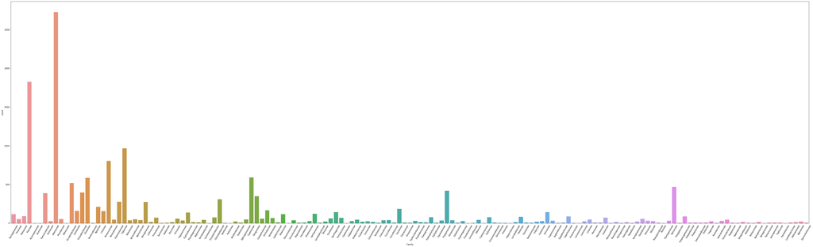

```python
fig_dims = (70,20)

fig, ax = plt.subplots(figsize=fig_dims)

sns.countplot(x='Family', data=data, ax=ax)

plt.xticks(rotation = 60)

plt.show()
```

```python
data['Scientific Name with Author'].nunique()
```

```
15436
```

```python
data['Scientific Name with Author'].value_counts()
```

```
Delphinium ×occidentale (S. Watson) S. Watson (pro sp.) [barbeyi × glaucum]      1
Thysanocarpus curvipes Hook. var. elegans (Fisch. & C.A. Mey.) B.L. Rob.         1
Eriogonum arcuatum Greene                                                        1
Epilobium palustre L. var. gracile (Farw.) Dorn                                  1
Fallopia japonica (Houtt.) Ronse Decr.                                           1
                                                                                ..
Artemisia campestris L. var. strutziae S.L. Welsh                                1
Paxistima Raf.                                                                   1
Potentilla concinna Richardson var. modesta (Rydb.) S.L. Welsh & B.C. Johnst.    1
Plagiobothrys nelsonii (Greene) I.M. Johnst.                                     1
Celtis canina Raf.                                                               1
Name: Scientific Name with Author, Length: 15436, dtype: int64
```

- There are 15436 unique values in "Scientific Name with Author" feature.
- This implies that the value_counts() is 1 for each value.

```python
print(data['Symbol'].nunique())
data['Symbol'].unique()
```

```
5520
```

```
array(['ABAR', 'ABCA', 'ABCO', ..., 'ZUCKI', 'ZYFA', 'ZYGOP'],
      dtype=object)
```

```python
data['Symbol'].value_counts()
```

```
MIGU      70
DECE      46
CRSU5     44
MACAC3    34
SAEX      32
          ..
HIAU       1
GRSUE      1
SCAC3      1
POFOM3     1
THERM      1
Name: Symbol, Length: 5520, dtype: int64
```

- There are 5520 unique values in "Symbol" feature.  
  #### Bar plot for the frequency of unique values in "Symbol" feature.

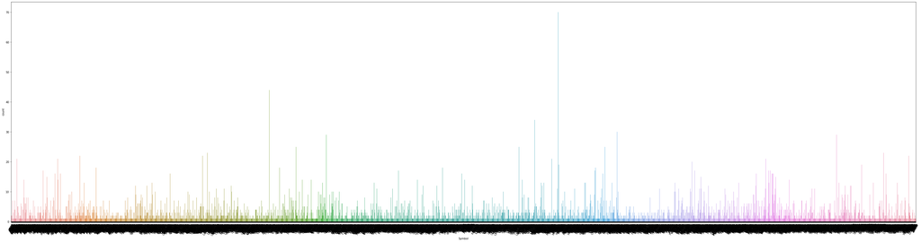

```python
fig_dims = (60,15)

fig, ax = plt.subplots(figsize=fig_dims)

sns.countplot(x='Symbol', data=data, ax=ax)

plt.xticks(rotation = 60)

plt.show()
```

### Data preprocessing:

The "Scientific Name with Author" column is split into 2 columns - "Scientific Name" and "Author".

```python
split = data['Scientific Name with Author'].str.split()
data['Scientific Name'] = split.str[0] + " " + split.str[1]
data['Author'] = split.str[-1]
data.drop('Scientific Name with Author', axis=1, inplace=True)
data.head()
```

|  | Symbol | Synonym Symbol | National Common Name | Family | Scientific Name | Author |
| --- | --- | --- | --- | --- | --- | --- |
| 0 | ABAR | NaN | clay sand verbena | Nyctaginaceae | Abronia argillosa | Goodrich |
| 1 | ABCA | NaN | Carleton's sand verbena | Nyctaginaceae | Abronia carletonii | Fisher |
| 2 | ABCO | NaN | white fir | Pinaceae | Abies concolor | Hildebr. |
| 3 | ABCO | ABCOC | NaN | Pinaceae | Abies concolor | concolor |
| 4 | ABEL | NaN | fragrant white sand verbena | Nyctaginaceae | Abronia elliptica | Nelson |

```python
data['Scientific Name'].nunique()
```

```
9712
```

```python
data['Scientific Name'].value_counts()
```

```
Lupinus argenteus              29
Chrysothamnus nauseosus        29
Deschampsia cespitosa          21
Chrysothamnus viscidiflorus    20
Mimulus guttatus               19
                               ..
Chenopodium retusum             1
Packera plattensis              1
Calamagrostis montanensis       1
Berteroa DC.                    1
Townsendia vreelandii           1
Name: Scientific Name, Length: 9712, dtype: int64
```

- There are 9712 unique values in "Scientific Name" feature.

```python
data['Author'].nunique()
```

```
2015
```

```python
data['Author'].value_counts()
```

```
L.          1014
Rydb.        676
Gray         593
Greene       539
Nutt.        337
            ...
Erskine        1
Songeon        1
dub.           1
Austin         1
dispersa       1
Name: Author, Length: 2015, dtype: int64
```

- There are 2015 unique values in "Author" feature.

After processing the dataset, we have to look at the strength of association between features as it will help us in Feature Selection. Passing the right features into our ML model will help the model converge faster and make right predictions. Correlation is the best metric to see how strongly our features are related to each other. However, pearson's correlation can only be calculated for numerical variables and cannot apply it to our categorical features.

```python
REPLACE = 'replace'
DROP = 'drop'
DROP_SAMPLES = 'drop_samples'
DROP_FEATURES = 'drop_features'
SKIP = 'skip'
DEFAULT_REPLACE_VALUE = 0.0
```

The conditional entropy function helps to calculate the Theil's U measure.

```python
def conditional_entropy(x,y,nan_strategy=REPLACE,nan_replace_value=DEFAULT_REPLACE_VALUE):
    """
    Calculates the conditional entropy of x given y: S(x|y)
    Wikipedia: https://en.wikipedia.org/wiki/Conditional_entropy
    **Returns:** float
    Parameters
    ----------
    x : list / NumPy ndarray / Pandas Series
        A sequence of measurements
    y : list / NumPy ndarray / Pandas Series
        A sequence of measurements
    nan_strategy : string, default = 'replace'
        How to handle missing values: can be either 'drop' to remove samples
        with missing values, or 'replace' to replace all missing values with
        the nan_replace_value. Missing values are None and np.nan.
    nan_replace_value : any, default = 0.0
        The value used to replace missing values with. Only applicable when
        nan_strategy is set to 'replace'.
    """
    if nan_strategy == REPLACE:
        x, y = replace_nan_with_value(x, y, nan_replace_value)
    elif nan_strategy == DROP:
        x, y = remove_incomplete_samples(x, y)
    y_counter = Counter(y)
    xy_counter = Counter(list(zip(x, y)))
    total_occurrences = sum(y_counter.values())
    entropy = 0.0
    for xy in xy_counter.keys():
        p_xy = xy_counter[xy] / total_occurrences
        p_y = y_counter[xy[1]] / total_occurrences
        entropy += p_xy * math.log(p_y / p_xy)
    return entropy
```

Theil's U function to measure the association between features.

```python
def theils_u(x, y, nan_strategy=REPLACE, nan_replace_value=DEFAULT_REPLACE_VALUE):
    if nan_strategy == REPLACE:
        x, y = replace_nan_with_value(x, y, nan_replace_value)
    elif nan_strategy == DROP:
        x, y = remove_incomplete_samples(x, y)
    s_xy = conditional_entropy(x, y)
    x_counter = Counter(x)
    total_occurrences = sum(x_counter.values())
    p_x = list(map(lambda n: n / total_occurrences, x_counter.values()))
    s_x = ss.entropy(p_x)
    if s_x == 0:
        return 1
    else:
        return (s_x - s_xy) / s_x
```

If a Theil'U matrix is calculated over a dataset with missing values, the below helper function will handle it.

```python
def replace_nan_with_value(x, y, value):
    x = [v if v == v and v is not None else value for v in x]  # NaN != NaN
    y = [v if v == v and v is not None else value for v in y]
    return x, y
```

```python
list_1 = []
matrix_1 = []

for i in data.columns:
    for j in data.columns:
        h = data[i]
        l = data[j]
        result = theils_u(h,l)
        list_1.append(result)

matrix_1.append(list_1)
```

```python
theils_u_matrix = np.reshape(matrix_1[0], (6,6))
theils_u_matrix
```

```
array([[1.        , 0.62381576, 0.39227829, 0.43560243, 0.96190784,
        0.56046089],
       [0.77848725, 1.        , 0.09849745, 0.3447234 , 0.91206129,
        0.58478428],
       [0.8935291 , 0.1797812 , 1.        , 0.36716811, 0.94042088,
        0.57711818],
       [1.        , 0.63414023, 0.37004985, 1.        , 1.        ,
        0.47486817],
       [0.8835579 , 0.67132127, 0.37923585, 0.40012146, 1.        ,
        0.58740305],
       [0.78927175, 0.65990553, 0.35680553, 0.29130276, 0.90056671,
        1.        ]])
```

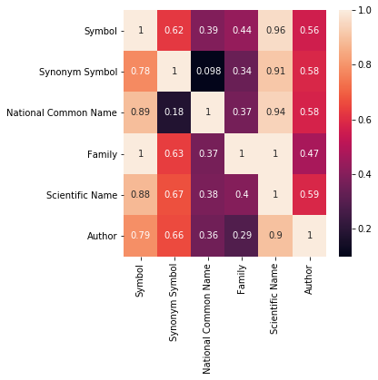

```python
sns.heatmap(theils_u_matrix, xticklabels=data.columns, yticklabels=data.columns, annot=True)
```

- By plotting a heat map of **Theils' U matrix**, we can see the **strength of association between various features**.
- From the heat map it's very evident that "Symbol" and "Scientific Name" are strongly associated.

As all our features are **categorical data** so we need to **encode these features to convert our categorical features into numerical features**. With such processeing we can pass these encoded categorical features into our machine learning algorithms as these algorithms only accept numbers and not strings.

### Integer encoding:

```python
x = list(data['Symbol'].unique())
dict_ = {}
for index, ele in enumerate(x):
  dict_.update({ele:index})
data['Symbol'] = data['Symbol'].map(dict_)

x = list(data['Synonym Symbol'].unique())
del x[0] # Delete NaN value from the list of unique classes so that NaN's are not encoded.
dict_ = {}
for index, ele in enumerate(x):
  dict_.update({ele:round(index)})
data['Synonym Symbol'] = data['Synonym Symbol'].map(dict_)

x = list(data['National Common Name'].unique())
del x[1] # Delete NaN value from the list of unique classes so that NaN's are not encoded.
dict_ = {}
for index, ele in enumerate(x):
  dict_.update({ele:round(index)})
data['National Common Name'] = data['National Common Name'].map(dict_)

x = list(data['Family'].unique())
dict_ = {}
for index, ele in enumerate(x):
  dict_.update({ele:index})
data['Family'] = data['Family'].map(dict_)

x = list(data['Scientific Name'].unique())
dict_ = {}
for index, ele in enumerate(x):
  dict_.update({ele:index})
data['Scientific Name'] = data['Scientific Name'].map(dict_)

x = list(data['Author'].unique())
dict_ = {}
for index, ele in enumerate(x):
  dict_.update({ele:index})
data['Author'] = data['Author'].map(dict_)

data.head()
```

|  | Symbol | Synonym Symbol | National Common Name | Family | Scientific Name | Author |
| --- | --- | --- | --- | --- | --- | --- |
| 0 | 0 | NaN | 0.0 | 0 | 0 | 0 |
| 1 | 1 | NaN | NaN | 0 | 1 | 1 |
| 2 | 2 | NaN | 1.0 | 1 | 2 | 2 |
| 3 | 2 | 0.0 | 2.0 | 1 | 2 | 3 |
| 4 | 3 | NaN | 3.0 | 0 | 3 | 4 |

```python
data.isnull().sum()
```

```
Symbol                     0
Synonym Symbol          5520
National Common Name       1
Family                     0
Scientific Name            0
Author                     0
dtype: int64
```

Print the missing values present in the current encoded dataset.

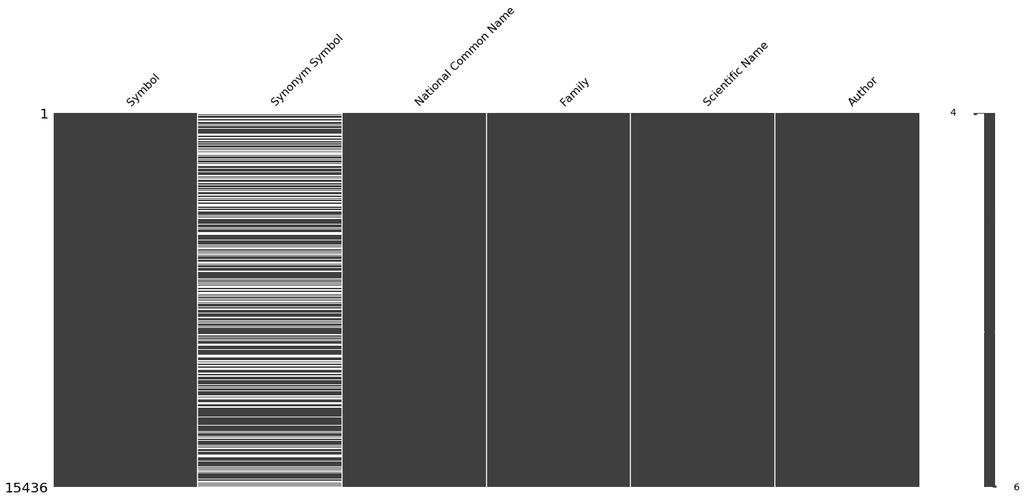

```python
msno.matrix(data)
```

### Data Imputation:

Using **K-Nearest neighbours**

```python
my_imputer = KNNImputer(n_neighbors=5)
imputed_my_data = pd.DataFrame(my_imputer.fit_transform(data))
imputed_my_data.columns = data.columns
imputed_my_data.index = data.index

imputed_my_data.head()
```

|  | Symbol | Synonym Symbol | National Common Name | Family | Scientific Name | Author |
| --- | --- | --- | --- | --- | --- | --- |
| 0 | 0.0 | 2.4 | 0.0 | 0.0 | 0.0 | 0.0 |
| 1 | 1.0 | 2.4 | 1.6 | 0.0 | 1.0 | 1.0 |
| 2 | 2.0 | 2.4 | 1.0 | 1.0 | 2.0 | 2.0 |
| 3 | 2.0 | 0.0 | 2.0 | 1.0 | 2.0 | 3.0 |
| 4 | 3.0 | 2.2 | 3.0 | 0.0 | 3.0 | 4.0 |

- We notice that **all the values in each column seem to be float**.
- This is because **KNN imputation** always uses mean of the nearest neighbours and **imputes the missing values with the mean**.

Now, to transform the values in each column to integers.

```python
def clean_balanced_dataset(data):
  col = ['Symbol', 'Synonym Symbol', 'National Common Name', 'Family', 'Scientific Name', 'Author']
  for index,value in enumerate(col):
    list_ = []
    for j in data[value]:
      list_.append(round(j))
    x = {value:list_}
    if index == 0:
      df = pd.DataFrame(x)
    else:
      df[value] = pd.DataFrame(x)
  return df
```

```python
imputed_my_data = clean_balanced_dataset(imputed_my_data)
```

- We can see that after KNN imputation, **all the NaN/missing values are reduced to 0**.

```python
imputed_my_data.isna().sum()
```

```
Symbol                  0
Synonym Symbol          0
National Common Name    0
Family                  0
Scientific Name         0
Author                  0
dtype: int64
```

```python
imputed_my_data.head(10)
```

|  | Symbol | Synonym Symbol | National Common Name | Family | Scientific Name | Author |
| --- | --- | --- | --- | --- | --- | --- |
| 0 | 0 | 2 | 0 | 0 | 0 | 0 |
| 1 | 1 | 2 | 2 | 0 | 1 | 1 |
| 2 | 2 | 2 | 1 | 1 | 2 | 2 |
| 3 | 2 | 0 | 2 | 1 | 2 | 3 |
| 4 | 3 | 2 | 3 | 0 | 3 | 4 |
| 5 | 3 | 1 | 2 | 0 | 4 | 5 |
| 6 | 3 | 2 | 2 | 0 | 5 | 6 |
| 7 | 3 | 3 | 2 | 0 | 6 | 7 |
| 8 | 3 | 4 | 2 | 0 | 7 | 6 |
| 9 | 4 | 3 | 4 | 0 | 4 | 8 |

The heat map of **Theils U matrix** after imputation of missing values.

```python
list_2 = []
matrix_2 = []

for i in imputed_my_data.columns:
  for j in imputed_my_data.columns:
    a = imputed_my_data[i]
    b = imputed_my_data[j]
    result_2 = theils_u(a,b)
    list_2.append(result_2)

matrix_2.append(list_2)

theils_u_matrix_2 = np.reshape(matrix_2[0], (6,6))
```

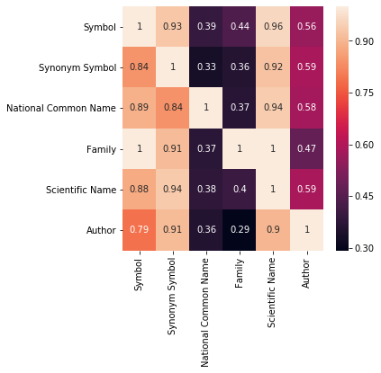

```python
sns.heatmap(theils_u_matrix_2, xticklabels=imputed_my_data.columns, yticklabels=imputed_my_data.columns, annot=True)
```

### Feature Selection:

Now that we have feature association matrix, we can move forward with feature selection.

**How does correlation help in feature selection?**  
Features are strongly associated are more linearly dependent and hence have almost the same effect on the dependent variable. So, when two features are strongly associated, we can drop one of the two features.  
Next, we compare the correlation between features and **remove one of two features that have a correlation higher than 0.9**.

```python
columns = np.full((theils_u_matrix_2.shape[0],), True, dtype=bool)
for i in range(theils_u_matrix_2.shape[0]):
    for j in range(i+1, theils_u_matrix_2.shape[0]):
        if theils_u_matrix_2[i,j] >= 0.9:
            if columns[j]:
                columns[j] = False
selected_columns = imputed_my_data.columns[columns]
```

```python
selected_columns
```

```
Index(['Symbol', 'National Common Name', 'Family', 'Author'], dtype='object')
```

After removing the features having more than 90% correlation score, we are left with **four variables.**

```python
data_final = imputed_my_data[selected_columns]
data_final.to_csv('dataset_plants.csv', index=False)
```

Saving the dataframe in a csv file for future purpose.

```python
X = data_final.drop('Family', axis=1)
Y = data_final['Family']
```

Next we will be selecting the **columns based on how they affect the p-value**.  
P-value gives us the probability of finding an observation under an assumption that a particular hypothesis is true. **This probability is used to accept or reject that hypothesis.**

```python
selected_columns = X.columns.values

def backwardElimination(x, Y, sl, columns):
    numVars = len(x[0])
    for i in range(0, numVars):
        regressor_OLS = sm.OLS(Y, x).fit()
        maxVar = max(regressor_OLS.pvalues).astype(float)
        if maxVar > sl:
            for j in range(0, numVars - i):
                if (regressor_OLS.pvalues[j].astype(float) == maxVar):
                    x = np.delete(x, j, 1)
                    columns = np.delete(columns, j)
    regressor_OLS.summary()
    return x, columns
SL = 0.05
data_modeled, selected_columns_pi = backwardElimination(X.values, Y.values, SL, selected_columns)
```

**If the p values is higher than the threshold, we discard that combination of features.**

```python
X = pd.DataFrame(data=data_modeled, columns=selected_columns_pi)
x = X.copy(deep=True)
x['Family'] = Y.values
x
```

|  | Symbol | National Common Name | Author | Family |
| --- | --- | --- | --- | --- |
| 0 | 0 | 0 | 0 | 0 |
| 1 | 1 | 2 | 1 | 0 |
| 2 | 2 | 1 | 2 | 1 |
| 3 | 2 | 2 | 3 | 1 |
| 4 | 3 | 3 | 4 | 0 |
| ... | ... | ... | ... | ... |
| 15431 | 5516 | 2 | 473 | 39 |
| 15432 | 5517 | 4221 | 7 | 39 |
| 15433 | 5518 | 4222 | 36 | 104 |
| 15434 | 5518 | 2 | 105 | 104 |
| 15435 | 5519 | 4223 | 36 | 104 |

15436 rows × 4 columns

We have performed Feature selection based on statsical measures and have collected the clean dataset.

### Data Visualization:

```python
x.corr()
```

|  | Symbol | National Common Name | Author | Family |
| --- | --- | --- | --- | --- |
| Symbol | 1.000000 | 0.321198 | 0.202423 | 0.244242 |
| National Common Name | 0.321198 | 1.000000 | 0.100797 | 0.048342 |
| Author | 0.202423 | 0.100797 | 1.000000 | 0.129261 |
| Family | 0.244242 | 0.048342 | 0.129261 | 1.000000 |

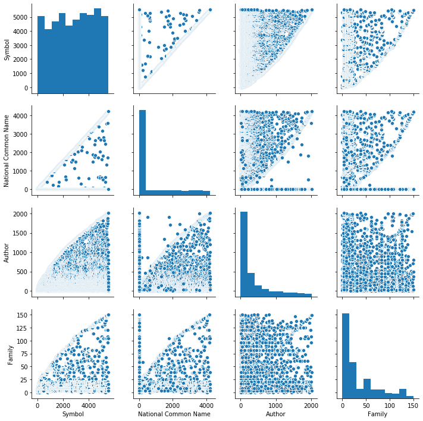

```python
sns.pairplot(x)
```